# kickstarter_class_tuncay

### KICKSTARTER PROJECT FROM KAGGLE

##### https://www.kaggle.com/kemical/kickstarter-projects/version/7

### BY TUNCAY DOGAN

##### https://github.com/ted2020

### FOR ECON 328 - FINAL PROJECT

```r
Sys.time()
```

```
[1] "2019-04-28 19:31:13 PDT"
```

# INTRODUCTION

#### Being able to reach out to clients or investors is one of the many great advantages of technology. Kickstarter enables makers to put forward their ideas and hopefully attain the attention of investors, who are on the lookout for the next big thing. Easiness of the platform, along with its early entrant market advantage, make Kickstarter a unique environment. There are many projects here, relateable to almost every aspect of life. But the changing preferences of people, with their desire of differentiated products can be observed in the data. Also, some sub-categories and categories are the leaders in terms of backers and percentage of fundedness. I will try to break it down as much as possible.

#### I am, here, looking at the issue from an angle of excess funding, timestamp variables, backers, and title wordcloud.

#### Kickstarter is a crowdsourcing to encourage creative projects for those who don't have much financial means. It's one of the go-to places for venture capitalists and angel investors. Even individuals can take part in projects with small capitals. The platform includes variety of projects from biotech to painting. If one puts forward a project for funding, that person is called a "creator." Each creator has to go through an immense task of providing a thorough analysis and objectives of the project. Outline of a project should indicate the stage, steps to be taken, possible final outcome, use of it, provide all the links and files, so that the investors can make an informed decision. If an investor decides to pledge an amount, he/she is called a "backer" and the amount contributed is named as "pledged amount." If the total asked funding by the creator has not been achieved, the pledged amounts of investors are not collected and the project doesn't go through. So, it's an all or none model. Therefore, creators should put strong creativity, research, and sincerity into their projects before they decide to go on to the platform of Kickstarter.

# SUMMARY

#### First, I will explore the data. I will create new variables that I am going to use, and see the levels, percentages by the sub and main category. Then I will look at which country has the most Kickstarter projects and which currency is the most used in transacting the business. Additonally, I will find which projects have higher than average funding and how many days the projects stay open.

#### Second, I will visualize excess pledge by sub and main categories, and what month and day provides the unusual fund pledging.

#### Third, I will create a wordcloud to analyze the names of projects.

#### Fourth, I will try to predict whether a project will be successful or fail. (logistic regression and randomforest and wordcloud)

```r
library(tidyverse)
library(caret)
library(janitor) # adorn_percentages
library(ggplot2)
library(wordcloud)
library(tidytext)
library(stringr)
library(text2vec)
library(tm)
library(NLP)
library(psych)
library(randomForest)
#library(party)
library(car)
library(InformationValue)
library(heuristica)
```

# EXPLORATORY

```r
kickstarter <- read.csv("ks-projects-201801.csv")
```

```r
# additional variables that are used are created here

kickstarter <- kickstarter %>% mutate(launch_year = as.numeric(as.character(format(as.Date(launched), "%Y"))))
kickstarter <- kickstarter %>% mutate(launch_month = format(as.Date(launched), "%B"))
kickstarter <- kickstarter %>% mutate(launch_month_numeric = as.numeric(as.character(format(as.Date(launched), "%m"))))
kickstarter <- kickstarter %>% mutate(launch_weekday = format(as.Date(launched), "%A"))
kickstarter <- kickstarter %>% mutate(launch_weekday_numeric = as.numeric(as.factor(kickstarter$launch_weekday)))
kickstarter <- kickstarter %>% mutate(excess_p=ifelse(((usd_pledged_real/usd_goal_real)-1)>0,((usd_pledged_real/usd_goal_real)-1),0))
kickstarter <- kickstarter %>% mutate(totaldays =  as.numeric(as.Date(deadline) - as.Date(launched)))
kickstarter <- kickstarter %>% mutate(category_numeric = as.numeric(as.factor(kickstarter$category)))
kickstarter <- kickstarter %>% mutate(main_category_numeric = as.numeric(as.factor(kickstarter$main_category)))
kickstarter <- kickstarter %>% mutate(state_numeric = as.numeric(as.factor(kickstarter$state)))

head(kickstarter,1)
```

| ID | name | category | main_category | currency | deadline | goal | launched | pledged | state | ... | launch_year | launch_month | launch_month_numeric | launch_weekday | launch_weekday_numeric | excess_p | totaldays | category_numeric | main_category_numeric | state_numeric |
| --- | --- | --- | --- | --- | --- | --- | --- | --- | --- | --- | --- | --- | --- | --- | --- | --- | --- | --- | --- | --- |
| 1000002330 | The Songs of Adelaide & Abullah | Poetry | Publishing | GBP | 2015-10-09 | 1000 | 2015-08-11 12:12:28 | 0 | failed | ... | 2015 | August | 8 | Tuesday | 6 | 0 | 59 | 109 | 13 | 2 |

```r
str(kickstarter)
```

```
'data.frame':	378661 obs. of  25 variables:
 $ ID                    : int  1000002330 1000003930 1000004038 1000007540 1000011046 1000014025 1000023410 1000030581 1000034518 100004195 ...
 $ name                  : Factor w/ 375765 levels "","\177Not Twins - New EP! \"The View from Down Here\"",..: 332541 135689 365010 344805 77349 206130 293462 69360 284139 290718 ...
 $ category              : Factor w/ 159 levels "3D Printing",..: 109 94 94 91 56 124 59 42 114 40 ...
 $ main_category         : Factor w/ 15 levels "Art","Comics",..: 13 7 7 11 7 8 8 8 5 7 ...
 $ currency              : Factor w/ 14 levels "AUD","CAD","CHF",..: 6 14 14 14 14 14 14 14 14 14 ...
 $ deadline              : Factor w/ 3164 levels "2009-05-03","2009-05-16",..: 2288 3042 1333 1017 2247 2463 1996 2448 1790 1863 ...
 $ goal                  : num  1000 30000 45000 5000 19500 50000 1000 25000 125000 65000 ...
 $ launched              : Factor w/ 378089 levels "1970-01-01 01:00:00",..: 243292 361975 80409 46557 235943 278600 187500 274014 139367 153766 ...
 $ pledged               : num  0 2421 220 1 1283 ...
 $ state                 : Factor w/ 6 levels "canceled","failed",..: 2 2 2 2 1 4 4 2 1 1 ...
 $ backers               : int  0 15 3 1 14 224 16 40 58 43 ...
 $ country               : Factor w/ 23 levels "AT","AU","BE",..: 10 23 23 23 23 23 23 23 23 23 ...
 $ usd.pledged           : num  0 100 220 1 1283 ...
 $ usd_pledged_real      : num  0 2421 220 1 1283 ...
 $ usd_goal_real         : num  1534 30000 45000 5000 19500 ...
 $ launch_year           : num  2015 2017 2013 2012 2015 ...
 $ launch_month          : chr  "August" "September" "January" "March" ...
 $ launch_month_numeric  : num  8 9 1 3 7 2 12 2 4 7 ...
 $ launch_weekday        : chr  "Tuesday" "Saturday" "Saturday" "Saturday" ...
 $ launch_weekday_numeric: num  6 3 3 3 3 1 2 2 5 1 ...
 $ excess_p              : num  0 0 0 0 0 ...
 $ totaldays             : num  59 60 45 30 56 35 20 45 35 30 ...
 $ category_numeric      : num  109 94 94 91 56 124 59 42 114 40 ...
 $ main_category_numeric : num  13 7 7 11 7 8 8 8 5 7 ...
 $ state_numeric         : num  2 2 2 2 1 4 4 2 1 1 ...
```

```r
anyNA(kickstarter)
```

TRUE

```r
kickstarter[!complete.cases(kickstarter),]
# looks like missing values are for the usd.pledged column, which i wont use in this assignment
# so i can ignore them
```

[output not shown]

```r
levels(kickstarter$state)
unique(kickstarter$launch_weekday_numeric)
unique(kickstarter$launch_weekday)
```

1. 'canceled'

2. 'failed'

3. 'live'

4. 'successful'

5. 'suspended'

6. 'undefined'

1. 6

2. 3

3. 1

4. 2

5. 5

6. 7

7. 4

1. 'Tuesday'

2. 'Saturday'

3. 'Friday'

4. 'Monday'

5. 'Thursday'

6. 'Wednesday'

7. 'Sunday'

```r
colnames(kickstarter)
```

1. 'ID'

2. 'name'

3. 'category'

4. 'main_category'

5. 'currency'

6. 'deadline'

7. 'goal'

8. 'launched'

9. 'pledged'

10. 'state'

11. 'backers'

12. 'country'

13. 'usd.pledged'

14. 'usd_pledged_real'

15. 'usd_goal_real'

16. 'launch_year'

17. 'launch_month'

18. 'launch_month_numeric'

19. 'launch_weekday'

20. 'launch_weekday_numeric'

21. 'excess_p'

22. 'totaldays'

23. 'category_numeric'

24. 'main_category_numeric'

25. 'state_numeric'

```r
levels(kickstarter$category)
n_distinct(kickstarter$category)
```

1. '3D Printing'

2. 'Academic'

3. 'Accessories'

4. 'Action'

5. 'Animals'

6. 'Animation'

7. 'Anthologies'

8. 'Apparel'

9. 'Apps'

10. 'Architecture'

11. 'Art'

12. 'Art Books'

13. 'Audio'

14. 'Bacon'

15. 'Blues'

16. 'Calendars'

17. 'Camera Equipment'

18. 'Candles'

19. 'Ceramics'

20. 'Children\'s Books'

21. 'Childrenswear'

22. 'Chiptune'

23. 'Civic Design'

24. 'Classical Music'

25. 'Comedy'

26. 'Comic Books'

27. 'Comics'

28. 'Community Gardens'

29. 'Conceptual Art'

30. 'Cookbooks'

31. 'Country & Folk'

32. 'Couture'

33. 'Crafts'

34. 'Crochet'

35. 'Dance'

36. 'Design'

37. 'Digital Art'

38. 'DIY'

39. 'DIY Electronics'

40. 'Documentary'

41. 'Drama'

42. 'Drinks'

43. 'Electronic Music'

44. 'Embroidery'

45. 'Events'

46. 'Experimental'

47. 'Fabrication Tools'

48. 'Faith'

49. 'Family'

50. 'Fantasy'

51. 'Farmer\'s Markets'

52. 'Farms'

53. 'Fashion'

54. 'Festivals'

55. 'Fiction'

56. 'Film & Video'

57. 'Fine Art'

58. 'Flight'

59. 'Food'

60. 'Food Trucks'

61. 'Footwear'

62. 'Gadgets'

63. 'Games'

64. 'Gaming Hardware'

65. 'Glass'

66. 'Graphic Design'

67. 'Graphic Novels'

68. 'Hardware'

69. 'Hip-Hop'

70. 'Horror'

71. 'Illustration'

72. 'Immersive'

73. 'Indie Rock'

74. 'Installations'

75. 'Interactive Design'

76. 'Jazz'

77. 'Jewelry'

78. 'Journalism'

79. 'Kids'

80. 'Knitting'

81. 'Latin'

82. 'Letterpress'

83. 'Literary Journals'

84. 'Literary Spaces'

85. 'Live Games'

86. 'Makerspaces'

87. 'Metal'

88. 'Mixed Media'

89. 'Mobile Games'

90. 'Movie Theaters'

91. 'Music'

92. 'Music Videos'

93. 'Musical'

94. 'Narrative Film'

95. 'Nature'

96. 'Nonfiction'

97. 'Painting'

98. 'People'

99. 'Performance Art'

100. 'Performances'

101. 'Periodicals'

102. 'Pet Fashion'

103. 'Photo'

104. 'Photobooks'

105. 'Photography'

106. 'Places'

107. 'Playing Cards'

108. 'Plays'

109. 'Poetry'

110. 'Pop'

111. 'Pottery'

112. 'Print'

113. 'Printing'

114. 'Product Design'

115. 'Public Art'

116. 'Publishing'

117. 'Punk'

118. 'Puzzles'

119. 'Quilts'

120. 'R&B'

121. 'Radio & Podcasts'

122. 'Ready-to-wear'

123. 'Residencies'

124. 'Restaurants'

125. 'Robots'

126. 'Rock'

127. 'Romance'

128. 'Science Fiction'

129. 'Sculpture'

130. 'Shorts'

131. 'Small Batch'

132. 'Software'

133. 'Sound'

134. 'Space Exploration'

135. 'Spaces'

136. 'Stationery'

137. 'Tabletop Games'

138. 'Taxidermy'

139. 'Technology'

140. 'Television'

141. 'Textiles'

142. 'Theater'

143. 'Thrillers'

144. 'Translations'

145. 'Typography'

146. 'Vegan'

147. 'Video'

148. 'Video Art'

149. 'Video Games'

150. 'Wearables'

151. 'Weaving'

152. 'Web'

153. 'Webcomics'

154. 'Webseries'

155. 'Woodworking'

156. 'Workshops'

157. 'World Music'

158. 'Young Adult'

159. 'Zines'

159

```r
levels(kickstarter$main_category)
n_distinct(kickstarter$main_category)
```

1. 'Art'

2. 'Comics'

3. 'Crafts'

4. 'Dance'

5. 'Design'

6. 'Fashion'

7. 'Film & Video'

8. 'Food'

9. 'Games'

10. 'Journalism'

11. 'Music'

12. 'Photography'

13. 'Publishing'

14. 'Technology'

15. 'Theater'

15

```r
levels(kickstarter$currency)
n_distinct(kickstarter$currency)
```

1. 'AUD'

2. 'CAD'

3. 'CHF'

4. 'DKK'

5. 'EUR'

6. 'GBP'

7. 'HKD'

8. 'JPY'

9. 'MXN'

10. 'NOK'

11. 'NZD'

12. 'SEK'

13. 'SGD'

14. 'USD'

14

```r
df1 <- (kickstarter %>% group_by(main_category,f_s=state_numeric==4) %>%
summarize(successful_count = n()))

df2 <- (kickstarter %>% group_by(main_category,f_s=state_numeric==2) %>%
summarize(failed_count = n()))

df3 <- (kickstarter %>% group_by(main_category,f_s=state_numeric==1) %>%
summarize(canceled_count = n()))

df4 <- (kickstarter %>% group_by(main_category,f_s=state_numeric==3) %>%
summarize(live_count = n()))

df5 <- (kickstarter %>% group_by(main_category,f_s=state_numeric==5) %>%
summarize(suspended_count = n()))

df6 <- (kickstarter %>% group_by(main_category,f_s=state_numeric==6) %>%
summarize(undefined_count = n()))
```

```r
merged <- Reduce(function(x, y) left_join(x, y, by=c("main_category","f_s"), all=TRUE), list(df1, df2, df3, df4, df5, df6))
merged <- merged %>% mutate_if(is.integer, ~replace(., is.na(.), 0))
merged   <- merged[seq(2,nrow(merged),2),]
merged
```

```
`mutate_if()` ignored the following grouping variables:
Column `main_category`
```

| main_category | f_s | successful_count | failed_count | canceled_count | live_count | suspended_count | undefined_count |
| --- | --- | --- | --- | --- | --- | --- | --- |
| Art | TRUE | 11510 | 14131 | 2222 | 194 | 96 | 0 |
| Comics | TRUE | 5842 | 4036 | 842 | 76 | 23 | 0 |
| Crafts | TRUE | 2115 | 5703 | 843 | 76 | 72 | 0 |
| Dance | TRUE | 2338 | 1235 | 163 | 18 | 13 | 1 |
| Design | TRUE | 10550 | 14814 | 4152 | 305 | 247 | 2 |
| Fashion | TRUE | 5593 | 14182 | 2650 | 250 | 138 | 3 |
| Film & Video | TRUE | 23623 | 32904 | 5755 | 332 | 117 | 854 |
| Food | TRUE | 6085 | 15969 | 2211 | 184 | 153 | 0 |
| Games | TRUE | 12518 | 16003 | 6202 | 287 | 220 | 1 |
| Journalism | TRUE | 1012 | 3137 | 523 | 31 | 52 | 0 |
| Music | TRUE | 24197 | 21752 | 3305 | 281 | 149 | 2234 |
| Photography | TRUE | 3305 | 6384 | 986 | 48 | 55 | 1 |
| Publishing | TRUE | 12300 | 23145 | 3602 | 299 | 66 | 462 |
| Technology | TRUE | 6434 | 20616 | 4715 | 377 | 424 | 3 |
| Theater | TRUE | 6534 | 3708 | 608 | 41 | 21 | 1 |

```r
# sum(merged$successful_count[seq(2,30,2)]) # sums only TRUE values
# sum(merged$successful_count[seq(1,30,2)])
#sum(merged[,3:8])
#sum(merged$successful_count)
# sum(merged$failed_count)+
# sum(merged$canceled_count)+
# sum(merged$live_count)+
# sum(merged$suspended_count)+
# sum(merged$undefined_count)
# dim(kickstarter)
# sum(merged[1,3:8])
# sum(merged[2,3:8])
# sum(kickstarter$fail_success==4)
```

```r
merged_p <- merged %>% adorn_percentages()
merged_p %>% arrange(desc(successful_count))
```

| main_category | f_s | successful_count | failed_count | canceled_count | live_count | suspended_count | undefined_count |
| --- | --- | --- | --- | --- | --- | --- | --- |
| Dance | TRUE | 0.6204883 | 0.3277601 | 0.04325902 | 0.004777070 | 0.003450106 | 2.653928e-04 |
| Theater | TRUE | 0.5987355 | 0.3397782 | 0.05571337 | 0.003756987 | 0.001924310 | 9.163383e-05 |
| Comics | TRUE | 0.5399760 | 0.3730474 | 0.07782605 | 0.007024679 | 0.002125890 | 0.000000e+00 |
| Music | TRUE | 0.4660619 | 0.4189684 | 0.06365808 | 0.005412381 | 0.002869910 | 4.302939e-02 |
| Art | TRUE | 0.4088374 | 0.5019359 | 0.07892587 | 0.006890917 | 0.003409939 | 0.000000e+00 |
| Film & Video | TRUE | 0.3715184 | 0.5174805 | 0.09050877 | 0.005221357 | 0.001840057 | 1.343084e-02 |
| Games | TRUE | 0.3553121 | 0.4542306 | 0.17603815 | 0.008146235 | 0.006244501 | 2.838409e-05 |
| Design | TRUE | 0.3508480 | 0.4926505 | 0.13807782 | 0.010143000 | 0.008214167 | 6.651147e-05 |
| Publishing | TRUE | 0.3084717 | 0.5804534 | 0.09033455 | 0.007498621 | 0.001655214 | 1.158650e-02 |
| Photography | TRUE | 0.3066147 | 0.5922627 | 0.09147416 | 0.004453103 | 0.005102514 | 9.277298e-05 |
| Food | TRUE | 0.2473376 | 0.6490936 | 0.08987074 | 0.007479067 | 0.006219007 | 0.000000e+00 |
| Fashion | TRUE | 0.2451350 | 0.6215813 | 0.11614656 | 0.010957223 | 0.006048387 | 1.314867e-04 |
| Crafts | TRUE | 0.2400954 | 0.6474061 | 0.09569758 | 0.008627540 | 0.008173459 | 0.000000e+00 |
| Journalism | TRUE | 0.2128286 | 0.6597266 | 0.10998948 | 0.006519453 | 0.010935857 | 0.000000e+00 |
| Technology | TRUE | 0.1975498 | 0.6329946 | 0.14476957 | 0.011575424 | 0.013018515 | 9.211213e-05 |

```r
merged_p <- merged %>% adorn_percentages()
merged_p %>% arrange(desc(failed_count))
```

| main_category | f_s | successful_count | failed_count | canceled_count | live_count | suspended_count | undefined_count |
| --- | --- | --- | --- | --- | --- | --- | --- |
| Journalism | TRUE | 0.2128286 | 0.6597266 | 0.10998948 | 0.006519453 | 0.010935857 | 0.000000e+00 |
| Food | TRUE | 0.2473376 | 0.6490936 | 0.08987074 | 0.007479067 | 0.006219007 | 0.000000e+00 |
| Crafts | TRUE | 0.2400954 | 0.6474061 | 0.09569758 | 0.008627540 | 0.008173459 | 0.000000e+00 |
| Technology | TRUE | 0.1975498 | 0.6329946 | 0.14476957 | 0.011575424 | 0.013018515 | 9.211213e-05 |
| Fashion | TRUE | 0.2451350 | 0.6215813 | 0.11614656 | 0.010957223 | 0.006048387 | 1.314867e-04 |
| Photography | TRUE | 0.3066147 | 0.5922627 | 0.09147416 | 0.004453103 | 0.005102514 | 9.277298e-05 |
| Publishing | TRUE | 0.3084717 | 0.5804534 | 0.09033455 | 0.007498621 | 0.001655214 | 1.158650e-02 |
| Film & Video | TRUE | 0.3715184 | 0.5174805 | 0.09050877 | 0.005221357 | 0.001840057 | 1.343084e-02 |
| Art | TRUE | 0.4088374 | 0.5019359 | 0.07892587 | 0.006890917 | 0.003409939 | 0.000000e+00 |
| Design | TRUE | 0.3508480 | 0.4926505 | 0.13807782 | 0.010143000 | 0.008214167 | 6.651147e-05 |
| Games | TRUE | 0.3553121 | 0.4542306 | 0.17603815 | 0.008146235 | 0.006244501 | 2.838409e-05 |
| Music | TRUE | 0.4660619 | 0.4189684 | 0.06365808 | 0.005412381 | 0.002869910 | 4.302939e-02 |
| Comics | TRUE | 0.5399760 | 0.3730474 | 0.07782605 | 0.007024679 | 0.002125890 | 0.000000e+00 |
| Theater | TRUE | 0.5987355 | 0.3397782 | 0.05571337 | 0.003756987 | 0.001924310 | 9.163383e-05 |
| Dance | TRUE | 0.6204883 | 0.3277601 | 0.04325902 | 0.004777070 | 0.003450106 | 2.653928e-04 |

```r
df7 <- (kickstarter %>% group_by(category,f_s=state_numeric==4) %>%
summarize(successful_count = n()))

df8 <- (kickstarter %>% group_by(category,f_s=state_numeric==2) %>%
summarize(failed_count = n()))

df9 <- (kickstarter %>% group_by(category,f_s=state_numeric==1) %>%
summarize(canceled_count = n()))

df10 <- (kickstarter %>% group_by(category,f_s=state_numeric==3) %>%
summarize(live_count = n()))

df11 <- (kickstarter %>% group_by(category,f_s=state_numeric==5) %>%
summarize(suspended_count = n()))

df12 <- (kickstarter %>% group_by(category,f_s=state_numeric==6) %>%
summarize(undefined_count = n()))
```

```r
merged2 <- Reduce(function(x, y) left_join(x, y, by=c("category","f_s"), all=TRUE), list(df7, df8, df9, df10, df11, df12))
merged2 <- merged2 %>% mutate_if(is.integer, ~replace(., is.na(.), 0))
merged2   <- merged2[seq(2,nrow(merged2),2),]
head(merged2)
```

```
`mutate_if()` ignored the following grouping variables:
Column `category`
```

| category | f_s | successful_count | failed_count | canceled_count | live_count | suspended_count | undefined_count |
| --- | --- | --- | --- | --- | --- | --- | --- |
| 3D Printing | TRUE | 242 | 326 | 91 | 8 | 15 | 1 |
| Academic | TRUE | 188 | 589 | 115 | 11 | 13 | 0 |
| Accessories | TRUE | 1073 | 1667 | 340 | 53 | 29 | 3 |
| Action | TRUE | 107 | 514 | 109 | 7 | 3 | 0 |
| Animals | TRUE | 63 | 166 | 18 | 3 | 5 | 0 |
| Animation | TRUE | 682 | 1531 | 306 | 16 | 6 | 0 |

```r
merged2_p <- merged2 %>% adorn_percentages()
head(merged2_p %>% arrange(desc(successful_count)),10)
```

| category | f_s | successful_count | failed_count | canceled_count | live_count | suspended_count | undefined_count |
| --- | --- | --- | --- | --- | --- | --- | --- |
| Chiptune | TRUE | 0.7714286 | 0.1714286 | 0.05714286 | 0.000000000 | 0.0000000000 | 0.0000000000 |
| Residencies | TRUE | 0.7246377 | 0.2608696 | 0.01449275 | 0.000000000 | 0.0000000000 | 0.0000000000 |
| Anthologies | TRUE | 0.6645408 | 0.2755102 | 0.04719388 | 0.011479592 | 0.0012755102 | 0.0000000000 |
| Dance | TRUE | 0.6640827 | 0.2911283 | 0.04134367 | 0.002153316 | 0.0008613264 | 0.0004306632 |
| Indie Rock | TRUE | 0.6395616 | 0.3024571 | 0.05479936 | 0.002651582 | 0.0005303164 | 0.0000000000 |
| Letterpress | TRUE | 0.6326531 | 0.3061224 | 0.02040816 | 0.020408163 | 0.0204081633 | 0.0000000000 |
| Country & Folk | TRUE | 0.6317681 | 0.3147607 | 0.04830375 | 0.004268704 | 0.0008986745 | 0.0000000000 |
| Classical Music | TRUE | 0.6303100 | 0.3034826 | 0.06008419 | 0.004209721 | 0.0019135094 | 0.0000000000 |
| Theater | TRUE | 0.6242029 | 0.3229418 | 0.04987955 | 0.001133626 | 0.0017004393 | 0.0001417033 |
| Performances | TRUE | 0.6159921 | 0.3326752 | 0.03849951 | 0.006910168 | 0.0059230010 | 0.0000000000 |

```r
merged2_p <- merged2 %>% adorn_percentages()
head(merged2_p %>% arrange(desc(failed_count)),10)
```

| category | f_s | successful_count | failed_count | canceled_count | live_count | suspended_count | undefined_count |
| --- | --- | --- | --- | --- | --- | --- | --- |
| Video | TRUE | 0.11915888 | 0.7803738 | 0.07943925 | 0.004672897 | 0.016355140 | 0.0000000000 |
| Food Trucks | TRUE | 0.12385845 | 0.7745434 | 0.08675799 | 0.011415525 | 0.003424658 | 0.0000000000 |
| Apps | TRUE | 0.05957447 | 0.7736801 | 0.15003940 | 0.012450749 | 0.004255319 | 0.0000000000 |
| Candles | TRUE | 0.12820513 | 0.7529138 | 0.11421911 | 0.004662005 | 0.000000000 | 0.0000000000 |
| Web | TRUE | 0.08596934 | 0.7502426 | 0.14477004 | 0.010867456 | 0.008150592 | 0.0000000000 |
| Farmer's Markets | TRUE | 0.16509434 | 0.7405660 | 0.08018868 | 0.009433962 | 0.004716981 | 0.0000000000 |
| Restaurants | TRUE | 0.16211422 | 0.7314651 | 0.09116708 | 0.010996807 | 0.004256829 | 0.0000000000 |
| Hip-Hop | TRUE | 0.15388548 | 0.7303170 | 0.10071575 | 0.007924335 | 0.006901840 | 0.0002556237 |
| Software | TRUE | 0.12171916 | 0.7224409 | 0.14140420 | 0.009842520 | 0.003937008 | 0.0006561680 |
| Mobile Games | TRUE | 0.08552264 | 0.7210732 | 0.17272219 | 0.011738401 | 0.008943544 | 0.0000000000 |

```r
# countries that do kickstarter projects the most to the least
# united states, great britain, canada, and australia lead the way in crowd funding.
# weirdly, these are all english spoken countries.
(kickstarter %>% group_by(country) %>%
summarize(n=n())) %>% arrange(desc(n))
```

| country | n |
| --- | --- |
| US | 292627 |
| GB | 33672 |
| CA | 14756 |
| AU | 7839 |
| DE | 4171 |
| N,0" | 3797 |
| FR | 2939 |
| IT | 2878 |
| NL | 2868 |
| ES | 2276 |
| SE | 1757 |
| MX | 1752 |
| NZ | 1447 |
| DK | 1113 |
| IE | 811 |
| CH | 761 |
| NO | 708 |
| HK | 618 |
| BE | 617 |
| AT | 597 |
| SG | 555 |
| LU | 62 |
| JP | 40 |

```r
# most preferred currencies
# dollar, euro, and british pound are the most used currencies in crowd funding.
(kickstarter %>% group_by(currency) %>%
summarize(n=n())) %>% arrange(desc(n))
```

| currency | n |
| --- | --- |
| USD | 295365 |
| GBP | 34132 |
| EUR | 17405 |
| CAD | 14962 |
| AUD | 7950 |
| SEK | 1788 |
| MXN | 1752 |
| NZD | 1475 |
| DKK | 1129 |
| CHF | 768 |
| NOK | 722 |
| HKD | 618 |
| SGD | 555 |
| JPY | 40 |

```r
by_excess_p <- (kickstarter %>% group_by(main_category,excess_p>0)) %>%
summarize(by_group_excess_p=sum(excess_p/n()))

by_excess_p   <- by_excess_p[seq(2,nrow(by_excess_p),2),]
by_excess_p
```

| main_category | excess_p > 0 | by_group_excess_p |
| --- | --- | --- |
| Art | TRUE | 5.1131469 |
| Comics | TRUE | 10.8190684 |
| Crafts | TRUE | 9.0844371 |
| Dance | TRUE | 0.2500935 |
| Design | TRUE | 4.5595111 |
| Fashion | TRUE | 2.8380101 |
| Film & Video | TRUE | 2.9961448 |
| Food | TRUE | 2.1918508 |
| Games | TRUE | 19.5581550 |
| Journalism | TRUE | 1.2200308 |
| Music | TRUE | 15.3790834 |
| Photography | TRUE | 0.8393530 |
| Publishing | TRUE | 4.8649677 |
| Technology | TRUE | 13.2552497 |
| Theater | TRUE | 0.6508495 |

```r
(kickstarter %>% group_by(main_category,f_s=state=="successful")) %>%
summarize(avgdays=sum(totaldays/n()))
```

| main_category | f_s | avgdays |
| --- | --- | --- |
| Art | FALSE | 35.07018 |
| Art | TRUE | 30.34005 |
| Comics | FALSE | 36.79586 |
| Comics | TRUE | 31.90859 |
| Crafts | FALSE | 32.39991 |
| Crafts | TRUE | 29.02695 |
| Dance | FALSE | 35.20699 |
| Dance | TRUE | 31.81480 |
| Design | FALSE | 35.80072 |
| Design | TRUE | 33.46777 |
| Fashion | FALSE | 33.35905 |
| Fashion | TRUE | 31.30914 |
| Film & Video | FALSE | 37.78149 |
| Film & Video | TRUE | 32.31004 |
| Food | FALSE | 34.92191 |
| Food | TRUE | 31.51159 |
| Games | FALSE | 34.00916 |
| Games | TRUE | 29.91277 |
| Journalism | FALSE | 35.26262 |
| Journalism | TRUE | 32.03656 |
| Music | FALSE | 37.28632 |
| Music | TRUE | 33.87759 |
| Photography | FALSE | 34.61413 |
| Photography | TRUE | 32.13737 |
| Publishing | FALSE | 35.47976 |
| Publishing | TRUE | 32.01220 |
| Technology | FALSE | 35.78217 |
| Technology | TRUE | 34.16211 |
| Theater | FALSE | 39.95661 |
| Theater | TRUE | 31.61570 |

```r
head((kickstarter %>% group_by(category, f_s=state=="successful")) %>%
summarize(avgdays=sum(totaldays/n())))
```

| category | f_s | avgdays |
| --- | --- | --- |
| 3D Printing | FALSE | 34.43764 |
| 3D Printing | TRUE | 32.50826 |
| Academic | FALSE | 35.66071 |
| Academic | TRUE | 31.76064 |
| Accessories | FALSE | 32.06549 |
| Accessories | TRUE | 30.31873 |

#### almost exclusively, average days the project is open for funding differ for succesful and failed projects. Failed projects tend to stay open longer than the successful ones.

#### it looks like the projects owners, to fill the pledge gap, keep their project open for investment longer than their counterparts which are pledged the required amount.

```r
describe(kickstarter$backers)
```

|  | vars | n | mean | sd | median | trimmed | mad | min | max | range | skew | kurtosis | se |
| --- | --- | --- | --- | --- | --- | --- | --- | --- | --- | --- | --- | --- | --- |
| X1 | 1 | 378661 | 105.6175 | 907.185 | 12 | 28.83679 | 17.7912 | 0 | 219382 | 219382 | 86.76232 | 13954.68 | 1.474248 |

```r
# 1 mad away from mean backers distribution by main_category
# mad = median absolute deviation
backed <- (kickstarter %>% group_by(backers,main_category) %>%
summarize(n=n()))

head((backed %>% arrange(desc(backers>(mean(kickstarter$backers)+mad(kickstarter$backers))))),10)
```

| backers | main_category | n |
| --- | --- | --- |
| 124 | Art | 22 |
| 124 | Comics | 18 |
| 124 | Crafts | 2 |
| 124 | Dance | 5 |
| 124 | Design | 37 |
| 124 | Fashion | 13 |
| 124 | Film & Video | 58 |
| 124 | Food | 17 |
| 124 | Games | 34 |
| 124 | Journalism | 4 |

```r
# 1 mad away from mean backers distribution by sub_category
backed <- (kickstarter %>% group_by(backers,category) %>%
summarize(n=n()))

head((backed %>% arrange(desc(backers>(mean(kickstarter$backers)+mad(kickstarter$backers))))),10)
```

| backers | category | n |
| --- | --- | --- |
| 124 | Action | 1 |
| 124 | Animation | 2 |
| 124 | Anthologies | 1 |
| 124 | Apparel | 4 |
| 124 | Art | 10 |
| 124 | Art Books | 7 |
| 124 | Camera Equipment | 1 |
| 124 | Ceramics | 1 |
| 124 | Children's Books | 10 |
| 124 | Childrenswear | 2 |

# VISUALIZATION

```
$title
[1] "excess pledge by main category"

attr(,"class")
[1] "labels"
```

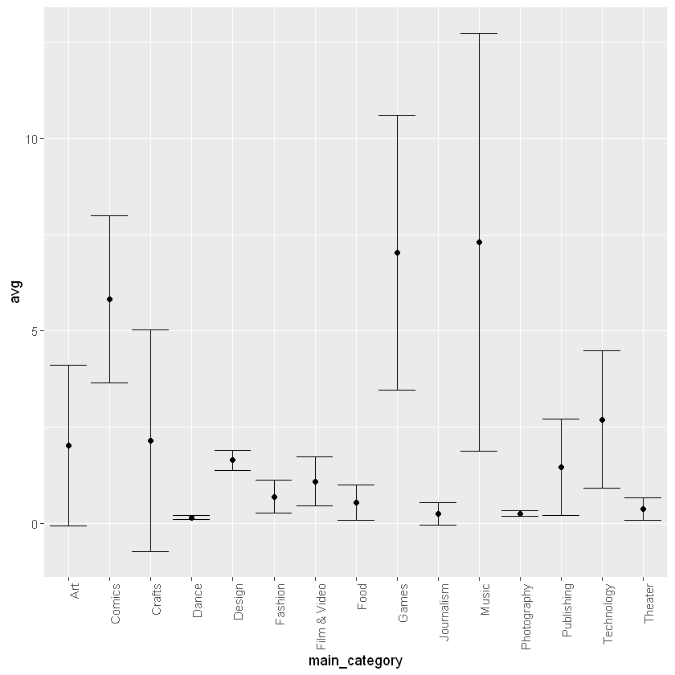

```r
kickstarter %>% group_by(main_category) %>%
	summarize(n = n(), avg = mean(excess_p), se = sd(excess_p)/sqrt(n())) %>%
	filter(n > 1) %>%
	mutate(reorder(main_category, avg)) %>%
	ggplot(aes(x = main_category, y = avg, ymin = avg - 2*se, ymax = avg + 2*se)) +
	geom_point() +
	geom_errorbar() +
	theme(axis.text.x = element_text(angle = 90, hjust = 1))
	ggtitle("excess pledge by main category")
```

#### games, music, and technology, and comics main categories seem to be the ones with the highest excess funding.

#### excess funding refers to the funds donated more than the project requires.

```r
by_excess_p2 <- (kickstarter %>% group_by(category,excess_p>0)) %>%
summarize(by_group_excess_p2=sum(excess_p/n()))

by_excess_p2   <- by_excess_p2[seq(2,nrow(by_excess_p2),2),]
head(by_excess_p2 %>% arrange(desc(by_group_excess_p2)))
```

| category | excess_p > 0 | by_group_excess_p2 |
| --- | --- | --- |
| Printing | TRUE | 252.39184 |
| Gaming Hardware | TRUE | 76.16636 |
| Latin | TRUE | 65.79265 |
| Radio & Podcasts | TRUE | 63.16044 |
| Interactive Design | TRUE | 51.87512 |
| R&B | TRUE | 46.96202 |

```
$title
[1] "excess pledge by sub-category, filtered by average excess 2-fold"

attr(,"class")
[1] "labels"
```

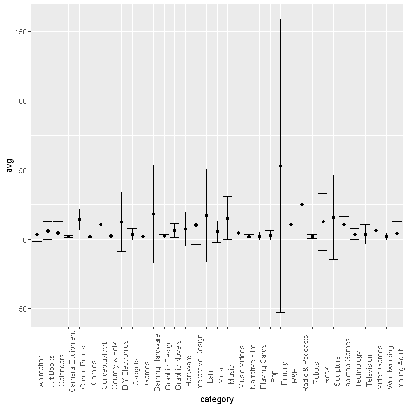

```r
kickstarter %>% group_by(category) %>%
	summarize(n = n(), avg = mean(excess_p), se = sd(excess_p)/sqrt(n())) %>%
	filter(avg > 2) %>%
	mutate(reorder(category, avg)) %>%
	ggplot(aes(x = category, y = avg, ymin = avg - 2*se, ymax = avg + 2*se)) +
	geom_point() +
	geom_errorbar() +
	theme(axis.text.x = element_text(angle = 90, hjust = 0.2))
	ggtitle("excess pledge by sub-category, filtered by average excess 2-fold")
```

#### in sub-category, i see that printing, gaming, latin, design, and music leads the way in excess funding.

#### i am assuming that this list includes printing due to high demand for 3D printing material and its vast applicability from bio-tech and arms industry.

#### https://www.researchnester.com/reports/us-3d-printing-market-analysis-opportunity-outlook-2024/88

#### another interesting excess funding here is from radio&podcasts. I looked it up and most of them require small amounts. That may be the reason why it's one of the highly excessly funded project topics

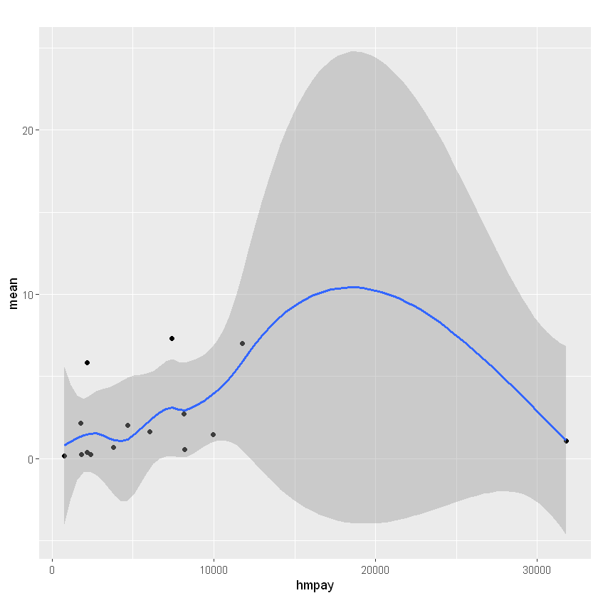

```r
kickstarter %>%
group_by(main_category) %>%
summarize(n=n(),howold=2019-first(launch_year),mean=mean(excess_p)) %>%
mutate (hmpay=n/howold)%>% #hmray=how many projects a year
ggplot(aes(hmpay, mean)) +
geom_point() +
geom_smooth() +
ggtitle("")
```

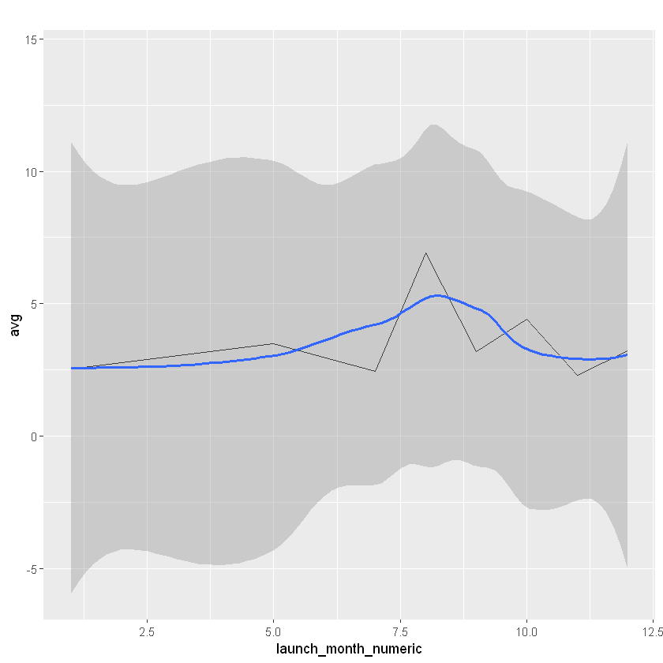

```r
kickstarter %>% group_by(launch_month_numeric) %>%
	summarize(n = n(), avg = mean(excess_p), se = sd(excess_p)/sqrt(n())) %>%
	filter(avg > 2) %>%
	mutate(reorder(launch_month_numeric, avg)) %>%
	ggplot(aes(x = launch_month_numeric, y = avg, ymin = avg - 2*se, ymax = avg + 2*se)) +
	geom_line() +
	geom_smooth() +
	ggtitle("")
```

```
$title
[1] ""

attr(,"class")
[1] "labels"
```

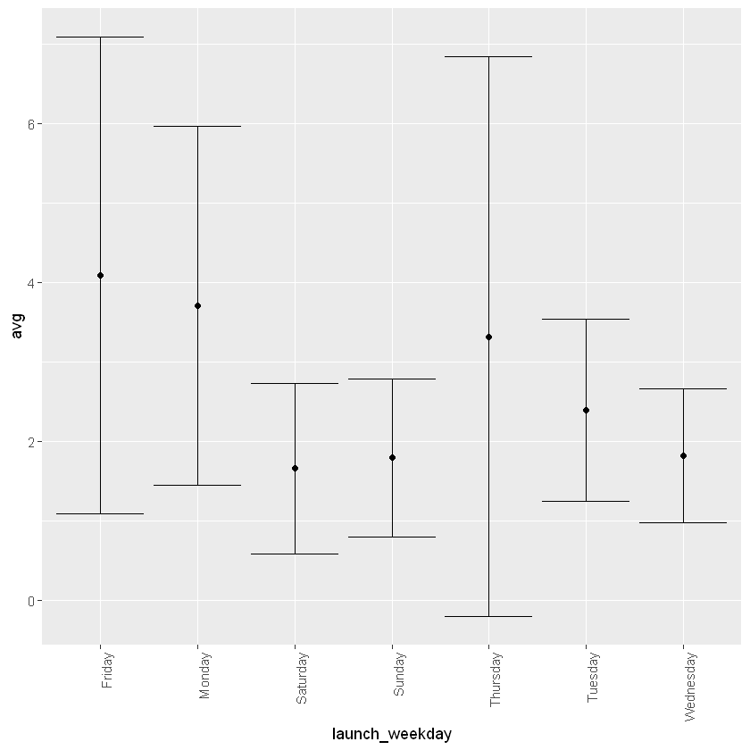

```r
kickstarter %>% group_by(launch_weekday) %>%
	summarize(n = n(), avg = mean(excess_p), se = sd(excess_p)/sqrt(n())) %>%
	filter(avg > 0) %>%
	mutate(reorder(launch_weekday, avg)) %>%
	ggplot(aes(x = launch_weekday, y = avg, ymin = avg - 2*se, ymax = avg + 2*se)) +
	geom_point() +
	geom_errorbar() +
	theme(axis.text.x = element_text(angle = 90, hjust = 1))
	ggtitle("")
```

#### friday, monday, and thurday looks like the day with the highest excess funding return

#### of course, these day and months with high observed returns are based on launch timestamp. There is going to be a lag between the launch and when it gets noticed by the investors

# WORDCLOUD

```r
names_of_projects <- (kickstarter$name)
names_of_projects <- tolower(names_of_projects)
names_of_projects <- gsub("[^[A-Za-z]"," ", names_of_projects)
names_of_projects <- gsub("\\b\\w{1,2}\\b", "", names_of_projects)
names_of_projects <- gsub("canceled", "", names_of_projects)
names_of_projects <- gsub("project", "", names_of_projects)

names_of_projects <- str_squish(names_of_projects)
head(names_of_projects)
```

1. 'the songs adelaide abullah'

2. 'greeting from earth zgac arts capsule for'

3. 'where hank'

4. 'toshicapital rekordz needs help complete album'

5. 'community film the art neighborhood filmmaking'

6. 'monarch espresso bar'

```r
data("stop_words")
```

```r
head(stop_words)
which(stop_words$lexicon == 'snowball')[1:10]
```

| word | lexicon |
| --- | --- |
| a | SMART |
| a's | SMART |
| able | SMART |
| about | SMART |
| above | SMART |
| according | SMART |

1. 572

2. 573

3. 574

4. 575

5. 576

6. 577

7. 578

8. 579

9. 580

10. 581

```r
stop_words_for_removal <- as.vector((stop_words %>% filter(lexicon=="snowball"))[1])
as.character(stop_words_for_removal)
```

'c("i", "me", "my", "myself", "we", "our", "ours", "ourselves", "you", "your", "yours", "yourself", "yourselves", "he", "him", "his", "himself", "she", "her", "hers", "herself", "it", "its", "itself", "they", "them", "their", "theirs", "themselves", "what", "which", "who", "whom", "this", "that", "these", "those", "am", "is", "are", "was", "were", "be", "been", "being", "have", "has", "had", "having", "do", "does", "did", "doing", "would", "should", "could", "ought", "i\'m", "you\'re", "he\'s", "she\'s", \n"it\'s", "we\'re", "they\'re", "i\'ve", "you\'ve", "we\'ve", "they\'ve", "i\'d", "you\'d", "he\'d", "she\'d", "we\'d", "they\'d", "i\'ll", "you\'ll", "he\'ll", "she\'ll", "we\'ll", "they\'ll", "isn\'t", "aren\'t", "wasn\'t", "weren\'t", "hasn\'t", "haven\'t", "hadn\'t", "doesn\'t", "don\'t", "didn\'t", "won\'t", "wouldn\'t", "shan\'t", "shouldn\'t", "can\'t", "cannot", "couldn\'t", "mustn\'t", "let\'s", "that\'s", "who\'s", "what\'s", "here\'s", "there\'s", "when\'s", "where\'s", "why\'s", "how\'s", "a", "an", "the", "and", "but", "if", "or", \n"because", "as", "until", "while", "of", "at", "by", "for", "with", "about", "against", "between", "into", "through", "during", "before", "after", "above", "below", "to", "from", "up", "down", "in", "out", "on", "off", "over", "under", "again", "further", "then", "once", "here", "there", "when", "where", "why", "how", "all", "any", "both", "each", "few", "more", "most", "other", "some", "such", "no", "nor", "not", "only", "own", "same", "so", "than", "too", "very")'

```r
names_of_projects_tm <- VCorpus(VectorSource(names_of_projects))
names_of_projects_tm <- tm_map(names_of_projects_tm,removeWords,stop_words_for_removal$word)
names_of_projects_tm <- tm_map(names_of_projects_tm,stripWhitespace)
names_of_projects_tm <- tm_map(names_of_projects_tm,removePunctuation)
inspect(names_of_projects_tm[[10]])
```

```
<<PlainTextDocument>>
Metadata:  7
Content:  chars: 35

studio sky documentary feature film
```

```r
NGramTokenizer <- function(x) {
  unlist(lapply(ngrams(words(x), GRAMS), paste, collapse = " "),
  use.names = FALSE)
}
```

```r
GRAMS <- 1
NGramTokenizer(names_of_projects_tm[[1]])
```

1. 'songs'

2. 'adelaide'

3. 'abullah'

```r
GRAMS <- 2
NGramTokenizer(names_of_projects_tm[[1]])
```

1. 'songs adelaide'

2. 'adelaide abullah'

```r
GRAMS <- 1
names_of_projects_dtm_1 <- DocumentTermMatrix(names_of_projects_tm,control = list(tokenize=NGramTokenizer))
names_of_projects_dtm_1 <- removeSparseTerms(names_of_projects_dtm_1,0.99)
```

```r
head(names_of_projects_dtm_1$dimnames$Terms)
tail(names_of_projects_dtm_1$dimnames$Terms)
```

1. 'album'

2. 'art'

3. 'book'

4. 'debut'

5. 'documentary'

6. 'film'

1. 'new'

2. 'one'

3. 'series'

4. 'short'

5. 'video'

6. 'world'

```r
GRAMS <- 2
names_of_projects_dtm_2 <- DocumentTermMatrix(names_of_projects_tm,control = list(tokenize=NGramTokenizer))
names_of_projects_dtm_2 <- removeSparseTerms(names_of_projects_dtm_2,0.997)
```

```r
head(names_of_projects_dtm_2$dimnames$Terms)
tail(names_of_projects_dtm_2$dimnames$Terms)
```

1. 'card game'

2. 'debut album'

3. 'feature film'

4. 'full length'

5. 'music video'

6. 'new album'

1. 'feature film'

2. 'full length'

3. 'music video'

4. 'new album'

5. 'playing cards'

6. 'short film'

```r
names_of_projects_dtm_freq_1 <- colSums(as.matrix(names_of_projects_dtm_1), na.rm = T)
names_of_projects_dtm_freq_1 <- sort(names_of_projects_dtm_freq_1,decreasing = T)
names_of_projects_dtm_freq_1[1:10]
#barplot(inst2_dtm_freq_1[1:20])
```

**album**

14239

**new**

13971

**film**

11762

**book**

10048

**game**

9261

**art**

8329

**music**

7685

**first**

6691

**help**

6590

**world**

6553

```r
names_of_projects_dtm_freq_2 <- colSums(as.matrix(names_of_projects_dtm_2), na.rm = T)
names_of_projects_dtm_freq_2 <- sort(names_of_projects_dtm_freq_2,decreasing = T)
names_of_projects_dtm_freq_2[1:10]
#barplot(inst2_dtm_freq_1[1:20])
```

**short film**

4103

**debut album**

2641

**new album**

2412

**music video**

1892

**card game**

1748

**feature film**

1634

**playing cards**

1584

**full length**

1452

**9**

<NA>

**10**

<NA>

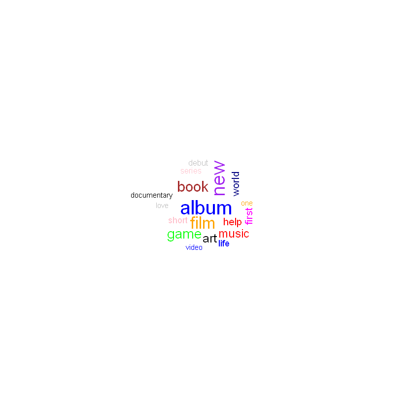

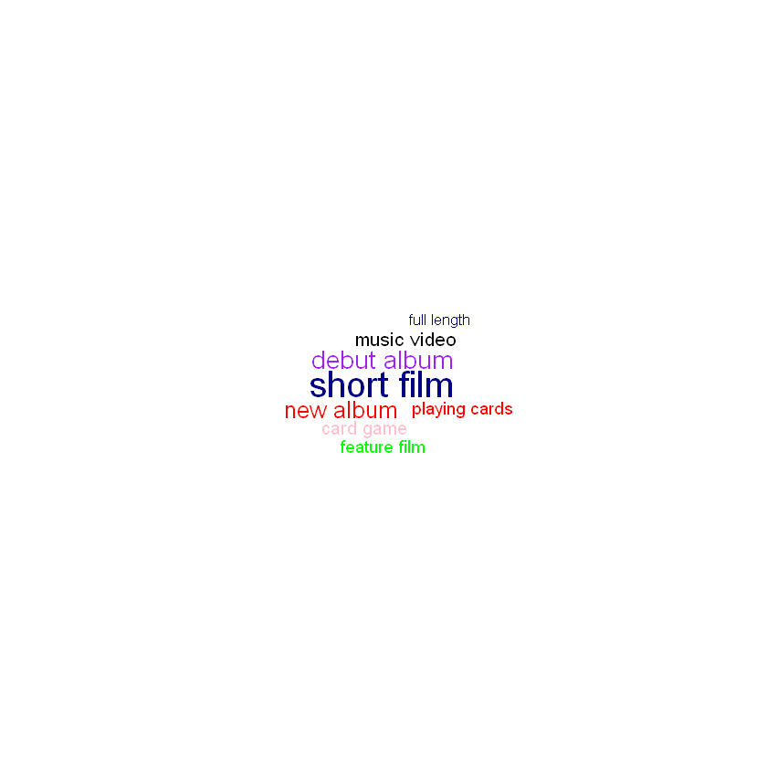

```r
colorlist = c("red","blue","green","red","pink","orange","grey","black","brown","navy","magenta","purple")
wordcloud(names(names_of_projects_dtm_freq_1),names_of_projects_dtm_freq_1, random.order = F, random.color = T, colors = colorlist,scale=c(2,.25))
wordcloud(names(names_of_projects_dtm_freq_2),names_of_projects_dtm_freq_2, random.order = F, random.color = T, colors = colorlist,scale=c(2,.25))
```

#### it's not a coincidence to observe the words "album" and "film" in the wordcloud, since the most succesful categories (see above) are including music, theatre, and dance. It looks like these categories along with the word "album" in their title are becoming more successful in kickstarter platform.

```r
bing <- sentiments %>% filter(lexicon == "bing") %>% dplyr::select(word,
sentiment)
```

```r
head(bing)
sort(table(bing$sentiment))
```

| word | sentiment |
| --- | --- |
| 2-faced | negative |
| 2-faces | negative |
| a+ | positive |
| abnormal | negative |
| abolish | negative |
| abominable | negative |

```
positive negative
    2006     4782
```

```r
tokens <- colnames(names_of_projects_dtm_1)
tokenMat <- cbind.data.frame(names_of_projects_dtm_1$i,names_of_projects_dtm_1$v,tokens[names_of_projects_dtm_1$j])
colnames(tokenMat) <- c("id","freq","word")
tokenMat$id <- as.character(tokenMat$id)
tokenMat$freq <- as.numeric(tokenMat$freq)
tokenMat$word <- as.character(tokenMat$word)
head(tokenMat)
dim(tokenMat)
word_count <- tapply(tokenMat$freq,tokenMat$id,sum)
tokenMat$n <- word_count[match(tokenMat$id,names(word_count))]
```

| id | freq | word |
| --- | --- | --- |
| 4 | 1 | album |
| 4 | 1 | help |
| 5 | 1 | art |
| 5 | 1 | film |
| 10 | 1 | documentary |
| 10 | 1 | film |

1. 130408

2. 3

```r
by_id_sentiment_bing <- inner_join(bing,tokenMat,by="word")
by_id_sentiment_bing.unique <- by_id_sentiment_bing[!duplicated(by_id_sentiment_bing$id),]
dim(by_id_sentiment_bing.unique)
head(by_id_sentiment_bing.unique)
```

1. 3958

2. 5

| word | sentiment | id | freq | n |
| --- | --- | --- | --- | --- |
| love | positive | 63 | 1 | 1 |
| love | positive | 69 | 1 | 1 |
| love | positive | 121 | 1 | 1 |
| love | positive | 139 | 1 | 2 |
| love | positive | 318 | 1 | 1 |
| love | positive | 344 | 1 | 2 |

```r
count_sentiment_by_id <- matrix(NA,length(kickstarter$name),length(unique(bing$sentiment)))
colnames(count_sentiment_by_id) <- unique(bing$sentiment)

for(i in 1:nrow(count_sentiment_by_id)){
    stp <- by_id_sentiment_bing.unique[by_id_sentiment_bing.unique$id == i,]
    sub_mat <- matrix(0,1,ncol(count_sentiment_by_id))
    colnames(sub_mat) <- colnames(count_sentiment_by_id)

  for(j in 1:nrow(stp)){
    sub_mat[1,(stp$sentiment[j-i])] <- sub_mat[1,(stp$sentiment[j-i])] + stp$freq[j]
  }

  count_sentiment_by_id[i,] <- sub_mat[1,]
}
count_sentiment_by_id<- as.data.frame(count_sentiment_by_id)
head(count_sentiment_by_id)
length(count_sentiment_by_id$negative)
c(negative=sum(count_sentiment_by_id$negative),positive=sum(count_sentiment_by_id$positive))
```

| negative | positive |
| --- | --- |
| 0 | 0 |
| 0 | 0 |
| 0 | 0 |
| 0 | 0 |
| 0 | 0 |
| 0 | 0 |

378661

**negative**

0

**positive**

4082

```r
n <- length(kickstarter$name)

sentiment_hat <- rbinom(n, 1, 0.70) # 1 for positive, 0 for negative

sentiment_hat <- as.data.frame(sentiment_hat)
head(sentiment_hat)

dim(sentiment_hat)
sum(sentiment_hat$sentiment_hat)
```

| sentiment_hat |
| --- |
| 1 |
| 1 |
| 1 |
| 1 |
| 1 |
| 0 |

1. 378661

2. 1

265032

```r
classification_bing <- ifelse(count_sentiment_by_id$positive > count_sentiment_by_id$negative, 1, 0)
confusion_matrix_bing <- table(sentiment_hat$sentiment_hat,classification_bing)
confusion_matrix_bing

##Overall Accuracy of Bing Lexicon vs sentiment_hat
accuracy <- sum(diag(confusion_matrix_bing))/sum(confusion_matrix_bing)
print('--Overall Accuracy--')
accuracy
```

```
   classification_bing
         0      1
  0 112470   1159
  1 262233   2799
```

```
[1] "--Overall Accuracy--"
```

0.304412125885687

# WILL PROJECT FAIL OR NOT?

```r
kickstarter2 <- (kickstarter[,c("state_numeric","category_numeric","main_category_numeric",
                                "backers","totaldays","launch_month_numeric","launch_weekday_numeric")])
```

```r
# for logistic regression, make it fail=0, success=1
# there is 6 states, 4th is success, convert 4 to 1,
# convert all the other numbers into 0.

kickstarter2$state_numeric[kickstarter2$state_numeric==1] <- 0
kickstarter2$state_numeric[kickstarter2$state_numeric==2] <- 0
kickstarter2$state_numeric[kickstarter2$state_numeric==3] <- 0
kickstarter2$state_numeric[kickstarter2$state_numeric==4] <- 1
kickstarter2$state_numeric[kickstarter2$state_numeric==5] <- 0
kickstarter2$state_numeric[kickstarter2$state_numeric==6] <- 0
```

```r
head(kickstarter2,1)
```

| state_numeric | category_numeric | main_category_numeric | backers | totaldays | launch_month_numeric | launch_weekday_numeric |
| --- | --- | --- | --- | --- | --- | --- |
| 0 | 109 | 13 | 0 | 59 | 8 | 6 |

```r
str(kickstarter2)
```

```
'data.frame':	378661 obs. of  7 variables:
 $ state_numeric         : num  0 0 0 0 0 1 1 0 0 0 ...
 $ category_numeric      : num  109 94 94 91 56 124 59 42 114 40 ...
 $ main_category_numeric : num  13 7 7 11 7 8 8 8 5 7 ...
 $ backers               : int  0 15 3 1 14 224 16 40 58 43 ...
 $ totaldays             : num  59 60 45 30 56 35 20 45 35 30 ...
 $ launch_month_numeric  : num  8 9 1 3 7 2 12 2 4 7 ...
 $ launch_weekday_numeric: num  6 3 3 3 3 1 2 2 5 1 ...
```

```r
set.seed(1)
test_index <- createDataPartition(y = kickstarter2$state_numeric, times = 1, p = 0.1, list = FALSE)
train <- kickstarter2[-test_index,]
test <- kickstarter2[test_index,]
```

```r
# LOGISTIC REGRESSION

# http://r-statistics.co/Logistic-Regression-With-R.html

logitpredtrain <- glm(state_numeric~category_numeric+backers+totaldays+launch_month_numeric+launch_weekday_numeric,
                      train, family=binomial(link="logit"))
```

```r
predicted <- predict(logitpredtrain, test, type="response")
```

```r
summary(logitpredtrain)
```

```
Call:
glm(formula = state_numeric ~ category_numeric + backers + totaldays +
    launch_month_numeric + launch_weekday_numeric, family = binomial(link = "logit"),
    data = train)

Deviance Residuals:
    Min       1Q   Median       3Q      Max
-8.4904  -0.7053  -0.6244   0.7053   2.3985

Coefficients:
                         Estimate Std. Error z value Pr(>|z|)
(Intercept)            -4.508e-01  1.885e-02 -23.918  < 2e-16 ***
category_numeric       -9.012e-04  9.445e-05  -9.543  < 2e-16 ***
backers                 1.937e-02  9.701e-05 199.706  < 2e-16 ***
totaldays              -2.410e-02  3.643e-04 -66.147  < 2e-16 ***
launch_month_numeric   -2.042e-02  1.276e-03 -15.999  < 2e-16 ***
launch_weekday_numeric -5.409e-03  1.965e-03  -2.753  0.00591 **
---
Signif. codes:  0 '***' 0.001 '**' 0.01 '*' 0.05 '.' 0.1 ' ' 1

(Dispersion parameter for binomial family taken to be 1)

    Null deviance: 442783  on 340793  degrees of freedom
Residual deviance: 330781  on 340788  degrees of freedom
AIC: 330793

Number of Fisher Scoring iterations: 10
```

```r
AIC(logitpredtrain)
BIC(logitpredtrain)
```

330792.877621601

330857.31182241

```r
# check for multicollinearity
vif(logitpredtrain)
```

**category_numeric**

1.00200663005289

**backers**

1.00611589899617

**totaldays**

1.00326392920343

**launch_month_numeric**

1.00113798547846

**launch_weekday_numeric**

1.00057758786645

```r
optCutOff <- optimalCutoff(test$state_numeric, predicted)[1]
misClassError(test$state_numeric, predicted, threshold = optCutOff)
# The lower the misclassification error, the better is your model
```

0.1592

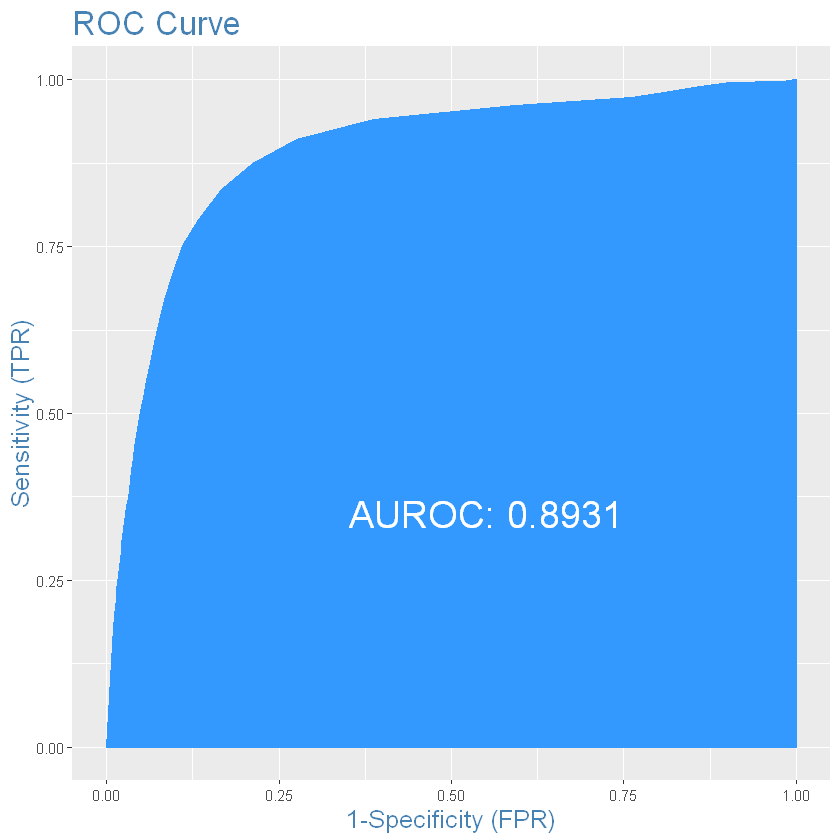

```r
plotROC(test$state_numeric, predicted)
#Receiver Operating Characteristics Curve traces the percentage of true positives accurately
#predicted by a given logit model as the prediction probability cutoff is lowered from 1 to 0.
#For a good model, as the cutoff is lowered,
#it should mark more of actual 1’s as positives and lesser of actual 0’s as 1’s.
#So for a good model, the curve should rise steeply,
#indicating that the TPR (Y-Axis) increases faster than the FPR (X-Axis) as the cutoff score decreases.
#Greater the area under the ROC curve, better the predictive ability of the model.
```

```r
Concordance(test$state_numeric, predicted)
# the higher the concordance, the better is the quality of model
```

**$Concordance**

0.894044539713294

**$Discordance**

0.105955460286706

**$Tied**

-4.16333634234434e-17

**$Pairs**

328496322

```r
sensitivity(test$state_numeric, predicted, threshold = optCutOff)
# Sensitivity (or True Positive Rate) is the percentage of 1’s (actuals) correctly predicted by the model
specificity(test$state_numeric, predicted, threshold = optCutOff)
# specificity is the percentage of 0’s (actuals) correctly predicted
# Specificity can also be calculated as 1 − False Positive Rate.
```

0.752414920493387

0.889507968372322

```r
confusMat <- confusionMatrix(test$state_numeric, predicted, threshold = optCutOff)
confusMat
```

|  | 0 | 1 |
| --- | --- | --- |
| 0 | 21712 | 3332 |
| 1 | 2697 | 10126 |

```r
accuracy <- sum(diag(as.matrix(confusMat)))/sum(confusMat)
print('--Overall Accuracy--')
accuracy
```

```
[1] "--Overall Accuracy--"
```

0.840784852246019

```r
# RANDOMFOREST
```

```r
pred_randomforest <- randomForest(state_numeric~category_numeric+backers+totaldays+launch_month_numeric+launch_weekday_numeric,
                      data=train,
                      importance=TRUE,
                      ntree=5)
```

```r
predicted_randomforest <- predict(pred_randomforest, test)
```

```r
confusMat_rs <- confusionMatrix(test$state_numeric, predicted_randomforest)
confusMat_rs
```

|  | 0 | 1 |
| --- | --- | --- |
| 0 | 21060 | 2172 |
| 1 | 3349 | 11286 |

```r
accuracy <- sum(diag(as.matrix(confusMat_rs)))/sum(confusMat_rs)
print('--Overall Accuracy--')
accuracy
```

```
[1] "--Overall Accuracy--"
```

0.854200227110677

# CONCLUSION